# The Influence of Climate Change on the Frequency and Severity of Natural Disasters

Author

540863213

**UNIVERSITY OF SYDNEY | DATA1001 | PROJECT 2**

# **👤** Client Bio and Recommendation

**Organisation:** [United Nations Office for Disaster Risk Reduction (UNDRR)](https://www.undrr.org/) [(Linkedin)](https://www.linkedin.com/company/undrr)

**Client**: [Paola Albrito, Director of the UNDRR](https://www.undrr.org/our-team/paola-albrito-biography) [(Linkedin)](https://www.linkedin.com/in/paola-albrito-91486145/?originalSubdomain=ch)

**Bio**: The United Nations Office for Disaster Risk Reduction (UNDRR) coordinates global efforts to reduce disaster risks and build resilience against natural hazards. It supports countries in implementing the Sendai Framework, promoting strategies to minimize the impact of disasters worldwide. **Paola Albrito** is the Director of the UNDRR, leading global initiatives to strengthen resilience and reduce disaster risks. She advocates for the implementation of the Sendai Framework, promoting sustainable and risk-informed development worldwide.

**Recommendation**:

- **Strengthen Disaster Preparedness and Response Systems in Highly Affected Areas**
  - Enhance early warnings, emergency protocols, and community training in high-risk areas to ensure effective, coordinated disaster response and minimize casualties.
- **Implement Targeted Mitigation Strategies for Specific Disaster Types**
  - Apply tailored measures like zoning, hazard mapping, and ecosystem management to reduce risks from specific disasters such as floods, earthquakes, or wildfires.
- **Enhance Climate-Resilient Infrastructure in Regions Prone to High-Casualty Disasters**
  - Build robust, adaptive infrastructure in vulnerable regions to withstand extreme weather, ensuring essential facilities stay operational during disasters.

# 📝 Evidence

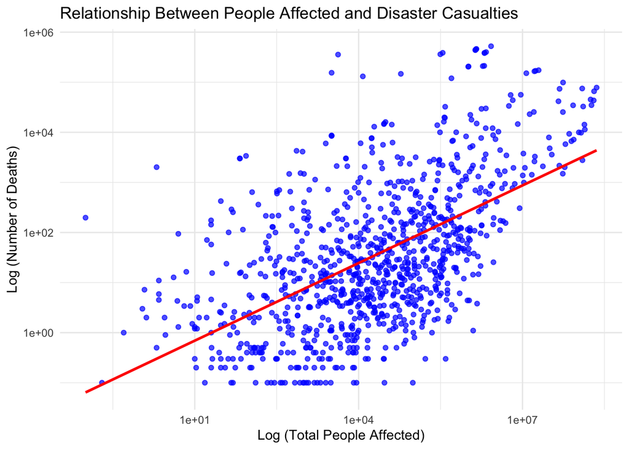

```r
suppressPackageStartupMessages(library(tidyverse))
library(grid)

natural_disasters = read.csv("~/Downloads/natural-disasters.csv")

# Scatter-Plot

# clean the data by removing rows with missing values in the specified columns
cleaned_data = natural_disasters %>%
  drop_na(Number.of.deaths.from.disasters, Number.of.total.people.affected.by.disasters) %>%
  filter(Number.of.deaths.from.disasters > 0, Number.of.total.people.affected.by.disasters > 0)

# convert the selected columns to numeric, ensuring proper data type for plotting
cleaned_data$Number.of.deaths.from.disasters = as.numeric(cleaned_data$Number.of.deaths.from.disasters)
cleaned_data$Number.of.total.people.affected.by.disasters = as.numeric(cleaned_data$Number.of.total.people.affected.by.disasters)

# create a scatter plot with ggplot
ggplot(cleaned_data, aes(x = Number.of.total.people.affected.by.disasters, y = Number.of.deaths.from.disasters)) +
  geom_point(color = "blue", alpha = 0.7) +
  geom_smooth(method = "lm", se = FALSE, color = "red") + # add a linear regression line in red, without confidence interval
  scale_x_log10() + scale_y_log10() + # apply log transformation to both axes
  labs(
    title = "Relationship Between People Affected and Disaster Casualties",
    x = "Log (Total People Affected)",
    y = "Log (Number of Deaths)"
  ) +
  theme_minimal()
```

The scatter plot reveals a clear positive relationship between the number of people affected by disasters and the number of casualties. This indicates that larger-scale disasters, which affect more people, tend to lead to higher fatalities. As climate change continues to intensify the frequency and scale of natural disasters, it is crucial for the UNDRR to prioritize enhancing disaster preparedness and response mechanisms in areas that are most vulnerable to such events. Early warning systems, emergency response plans, and resource allocation should be improved to minimize casualties during large-scale disasters.

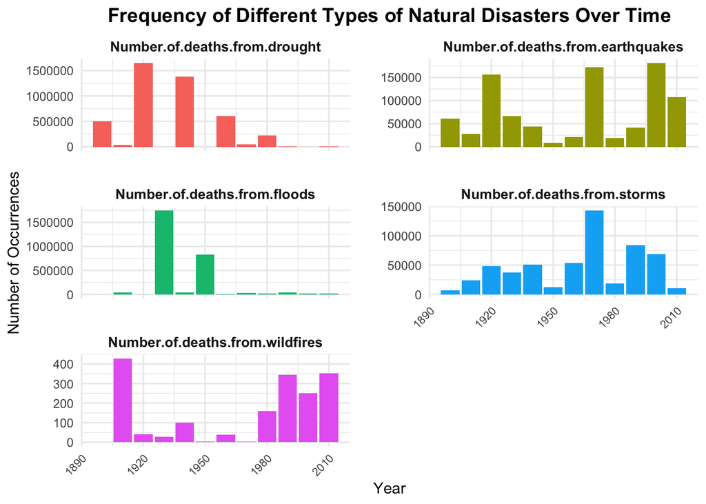

```r
# Facet Grid Bar Graph

disaster_types_over_time = natural_disasters %>%
  select(Year,
         Number.of.deaths.from.drought,
         Number.of.deaths.from.earthquakes,
         Number.of.deaths.from.floods,
         Number.of.deaths.from.storms,
         Number.of.deaths.from.wildfires) %>%

  # reshape data to have a longer format, making disaster types a single column
  pivot_longer(cols = -Year,
               names_to = "DisasterType",
               values_to = "Occurrences") %>%

  group_by(Year, DisasterType) %>%
  summarize(Frequency = sum(Occurrences, na.rm = TRUE), .groups = "drop")

# create a bar plot to visualize the frequency of different disaster types over time
ggplot(disaster_types_over_time, aes(x = Year, y = Frequency, fill = DisasterType)) +
  geom_bar(stat = "identity") +
  facet_wrap(~ DisasterType, scales = "free_y", ncol = 2) +

  labs(
    title = "Frequency of Different Types of Natural Disasters Over Time",
    x = "Year", # Label for x-axis
    y = "Number of Occurrences" # Label for y-axis
  ) +

  theme_minimal() +
  theme(
    axis.text.x = element_text(angle = 45, hjust = 1, size = 8),
    plot.title = element_text(hjust = 0.5, face = "bold", size = 14),
    strip.text = element_text(size = 10, face = "bold"),
    panel.spacing = unit(1.5, "lines"), # increase space between panels
    legend.position = "none"
  )
```

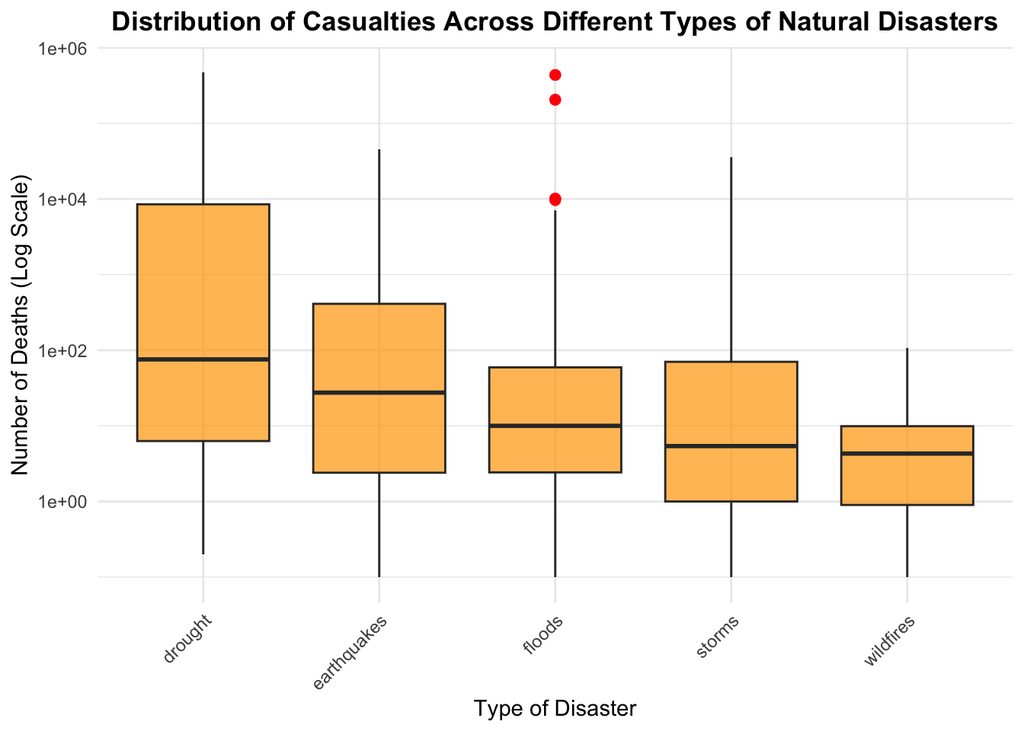

```r
# Box Plot

casualty_data = natural_disasters %>%
  select(Number.of.deaths.from.drought,
         Number.of.deaths.from.earthquakes,
         Number.of.deaths.from.floods,
         Number.of.deaths.from.storms,
         Number.of.deaths.from.wildfires) %>%

  # reshape data to have a longer format, where each row corresponds to a specific disaster type
  pivot_longer(cols = everything(),
               names_to = "DisasterType",
               values_to = "Casualties") %>%

  drop_na(Casualties) %>%
  filter(Casualties > 0)


casualty_data$DisasterType <- gsub("Number.of.deaths.from.", "", casualty_data$DisasterType)

# create a box plot to visualize the distribution of casualties for each type of natural disaster
ggplot(casualty_data, aes(x = DisasterType, y = Casualties)) +
  geom_boxplot(fill = "orange", alpha = 0.7, outlier.color = "red", outlier.size = 2) +
  scale_y_log10() +
  labs(
    title = "Distribution of Casualties Across Different Types of Natural Disasters",
    x = "Type of Disaster",
    y = "Number of Deaths (Log Scale)"
  ) +

  theme_minimal() +
  theme(
    axis.text.x = element_text(angle = 45, hjust = 1), # Rotate x-axis labels for better readability
    plot.title = element_text(hjust = 0.5, face = "bold") # Center and style the title
  )
```

# [🖊️](https://emojipedia.org/pen) Appendix: Defense of Approach

Paola Albrito, Director of the UNDRR, was chosen as the client because of her focus on disaster risk reduction. Since the project topic is “The Influence of Climate Change on the Frequency and Severity of Natural Disasters,” it made sense to address someone leading efforts to reduce disaster impacts worldwide. Choosing her as the client shaped the report to highlight how climate change affects disaster risks and the importance of global strategies to manage these risks. The content was tailored to provide clear insights and recommendations that align with the UNDRR’s goals of reducing the impact of disasters.

The topic, **“The Influence of Climate Change on the Frequency and Severity of Natural Disasters,”** required diverse methods to provide comprehensive insights:

### **HATPC:**

   **H - Hypotheses**

   **Null Hypothesis (H<sub>0</sub>):** There is no significant correlation between the total number of people impacted by natural disasters and the number of fatalities. In simpler terms, the regression line has a slope of zero.

   **Alternative Hypothesis (H<sub>1</sub>):** There is a strong correlation between the total number of people impacted by natural disasters and the number of fatalities. This means that the regression line has a slope that is not zero.

### **A - Assumptions**

   For the linear regression analysis, the following assumptions are made:
   1. **Linearity**: The linear relationship exists between the total number of people affected when log-transformed and the number of deaths when log-transformed. The scatter plot was used for visual assessment.
   2. **Independence**: The observations are independent of each other, implying that the data points do not influence one another.
   3. **Homoscedasticity**: It implies that the errors’ variance remains constant regardless of the predictor variable’s level.
   4. **Normality of Residuals**: Residuals should follow a roughly normal distribution to be considered normal.
   5. **No Multicollinearity**: There is no problem with multicollinearity in this basic linear regression model with only one predictor.

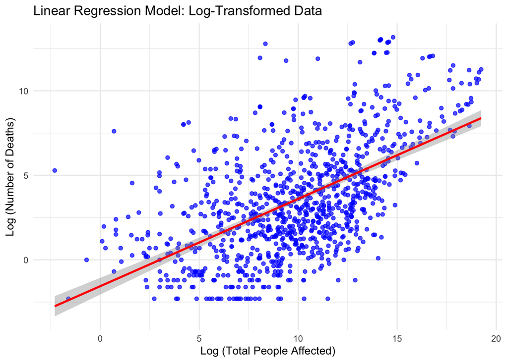

```r
library(tidyverse)

# prepare the dataset for regression analysis
linear_model_data = cleaned_data %>%
  filter(Number.of.total.people.affected.by.disasters > 0, Number.of.deaths.from.disasters > 0)

lm_model = lm(log(Number.of.deaths.from.disasters) ~ log(Number.of.total.people.affected.by.disasters), data = linear_model_data)

summary(lm_model)

# the regression line on the scatter plot
ggplot(linear_model_data, aes(x = log(Number.of.total.people.affected.by.disasters), y = log(Number.of.deaths.from.disasters))) +
  geom_point(color = "blue", alpha = 0.7) +
  geom_smooth(method = "lm", se = TRUE, color = "red") +
  labs(
    title = "Linear Regression Model: Log-Transformed Data",
    x = "Log (Total People Affected)",
    y = "Log (Number of Deaths)"
  ) +
  theme_minimal()
```

[output not shown]

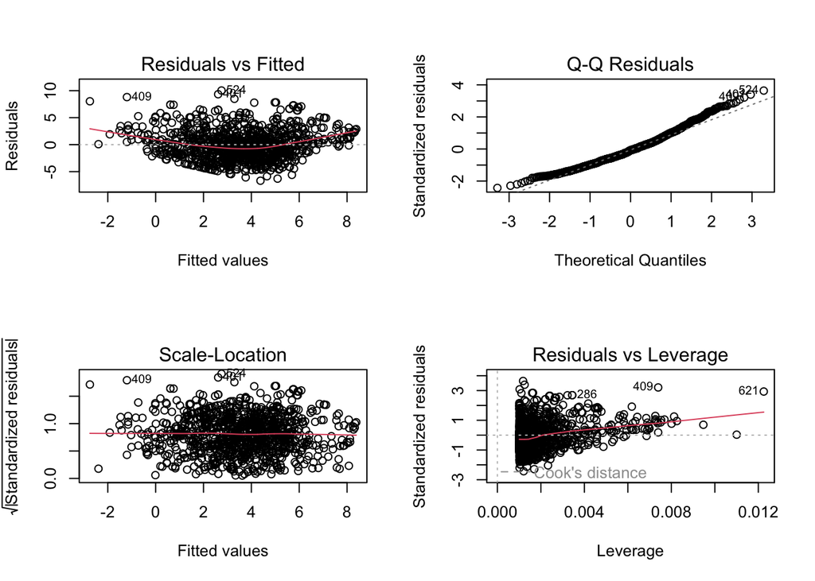

```r
par(mfrow = c(2, 2))  # Arrange plots in a 2x2 grid
plot(lm_model)
```

### **P - P-value and Significance**

- **P-value: `< 2e-16`**
- Since the p-value is significantly below 0.05, we can reject the null hypothesis. This suggests a notable correlation between the total number of individuals impacted by disasters and the number of fatalities.
- **R-squared: 0.3184**
  - The R-squared value suggests that around 31.8% of the variance in death tolls can be attributed to the variance in the total number of disaster-affected individuals. Although a correlation is observed, the R-squared value indicates that there are likely other variables affecting the death rate, and the model could benefit from the incorporation of more factors.

### **C - Conclusion**

**Based on the results of the linear regression analysis, we conclude the following:**

1. There is a **significant positive relationship** between the number of people affected by natural disasters and the number of deaths. The p-value (< 2e-16) strongly supports this finding.
2. A **slope of 0.5166** suggests that when the quantity of people impacted by disasters rises, the number of deaths also generally rises, based on a log-transformed scale. This implies that disasters affecting more people are typically linked to increased casualties.
3. However, the **R-squared value (0.3184)** shows that this predictor by itself does not completely account for the variability in the number of deaths. Disaster preparedness, geographical location, and type of disaster can also have significant impacts on the severity of fatalities.

### Limitations

The analysis had a few limitations. First, the **data might have gaps or be inconsistent**, as disaster reporting varies by region. Second, the **R-squared value was low**, meaning other factors (like preparedness or infrastructure) affect casualty rates and weren’t included in the model. Using a **log transformation** helped handle extreme values but might have hidden some details. Lastly, the study didn’t account for **geographic differences**, so patterns may vary across different regions.

# ⚖️ Ethics Statement

In conducting this analysis, the following ethical guidelines have been adhered to:

**Shared Value: Professional Integrity**  
Throughout the analysis, accuracy, transparency, and honesty were maintained. Data sources were responsibly handled, and unbiased statistical methods were applied. This approach ensures trust and credibility, crucial for informed policy decisions.

**Ethical Principle: Respect for Data Confidentiality**  
The analysis respected data confidentiality, using publicly available data without disclosing sensitive information. Results were presented in aggregate, protecting privacy while providing reliable insights. This ethical foundation supports responsible disaster risk analysis for organizations like the UNDRR.

These guidelines ensure that findings are trustworthy and useful for stakeholders in disaster risk reduction.

# 🤝 Acknowledgements

**Allen, M. R., Dube, O. P., Solecki, W., Aragón-Durand, F., & Cramer, W. (2018).**  
https://www.ipcc.ch/report/sr15/  
This report from the Intergovernmental Panel on Climate Change (IPCC) highlights how climate change increases the frequency and severity of natural disasters. The study provides insights on how global warming affects weather patterns, making events like heatwaves, floods, and storms more extreme and unpredictable.

Coumou, Dim, and Stefan Rahmstorf. “A Decade of Weather Extremes.” Nature Climate Change, vol. 2, no. 7, July 2012, pp. 491–496, https://nature.com/articles/nclimate1452 https://doi.org/10.1038/nclimate1452.

**Articles and Blogs:**  
https://pmc.ncbi.nlm.nih.gov/articles/PMC6069477/  
https://earthobservatory.nasa.gov/features/RisingCost/rising_cost5.php  
https://knowledge.aidr.org.au/resources/natural-hazards-and-climate-change/  
**Removing Warnings:** [https://stackoverflow.com/questions/45399587/how- to-remove-warning](https://stackoverflow.com/questions/45399587/how-to-remove-warning-messages-in-r-markdown-document)

**Data Cleaning:** https://stackoverflow.com/questions/45527598/data-cleaning-with-r  
https://www.geeksforgeeks.org/data-cleaning-in-r/

**Ed Posts:**  
https://edstem.org/au/courses/16787/discussion/2285233  
https://edstem.org/au/courses/16787/discussion/2301513